# Introduction to R

## What is R?

- R is a free open-source program that is
- Used to do statistics in both academia and industry.
- Many online resources for R, for both beginners and experts.
- Good skill to put on your cv.

## A fancy calculator

R can be used as a fancy calculator

```r
2+2
```

```
## [1] 4
```

```r
sin(3.14)
```

```
## [1] 0.001592653
```

```r
exp(1)
```

```
## [1] 2.718282
```

```r
log(2.71)
```

```
## [1] 0.9969486
```

```r
pi
```

```
## [1] 3.141593
```

Variables can be assigned in the following way

```r
x <- 1+2+3+4+5+6
x*2
```

```
## [1] 42
```

## Entering data by hand into R

R is designed to store data as vectors \(x = (x_1, x_2, \ldots, x_n)\) that is lists of numbers.

```r
y <- c(1,2,3,4,5,6,7,8,9)
y
```

```
## [1] 1 2 3 4 5 6 7 8 9
```

## Basic operations with vectors

R has many built in common operations that are useful for statistics:

```r
x <- c(1,2,3,4,5,6,7,8,9,10)
x
```

```
##  [1]  1  2  3  4  5  6  7  8  9 10
```

```r
sum(x)
```

```
## [1] 55
```

```r
mean(x)
```

```
## [1] 5.5
```

```r
sd(x)
```

```
## [1] 3.02765
```

```r
var(x)
```

```
## [1] 9.166667
```

R will do certain operations component wise:

```r
 x <- c(1,2,3,4,5)
y <- c(6,7,8,9,10)
z=x+y
z
```

```
## [1]  7  9 11 13 15
```

```r
sin(z)
```

```
## [1]  0.6569866  0.4121185 -0.9999902  0.4201670  0.6502878
```

It is often necessary to add or delete data from a vector:

```r
x<- c(0.1, 0.2, 0.3, 0.4, 0.5)
x <- x[-5]
x
```

```
## [1] 0.1 0.2 0.3 0.4
```

```r
x <- c(x, 5.5)
x
```

```
## [1] 0.1 0.2 0.3 0.4 5.5
```

## Random variables in R

- R can be used to simulate coin flips and dice roll.
- R does not use true randomness.

```r
x<- rbinom(12,1, 0.5)
x
```

```
##  [1] 0 1 1 0 0 0 0 0 0 0 1 0
```

```r
z <- sample(6,12, replace =TRUE)
z
```

```
##  [1] 2 3 3 6 5 2 6 4 6 5 4 4
```

```r
x<- rnorm(10, 5, 1)
x
```

```
##  [1] 5.397613 4.621272 4.500198 3.865283 5.204967 5.673333 3.231157 3.856156
##  [9] 5.348239 3.087446
```

```r
z <- runif(10, min=-1, max=1)
z
```

```
##  [1]  0.5121779  0.8852102  0.4035998  0.8742291 -0.3314065 -0.3301936
##  [7]  0.6630193 -0.6573704 -0.3727413 -0.8491085
```

```r
z <- rexp(10, 2)
z
```

```
##  [1] 0.243909000 0.846406905 0.894939437 0.075192600 0.939676119 1.263858433
##  [7] 1.060914981 0.554971271 0.663786483 0.001729772
```

```r
z<- rpois(7, 1)
print(z)
```

```
## [1] 2 1 3 2 2 1 0
```

## Histograms in R

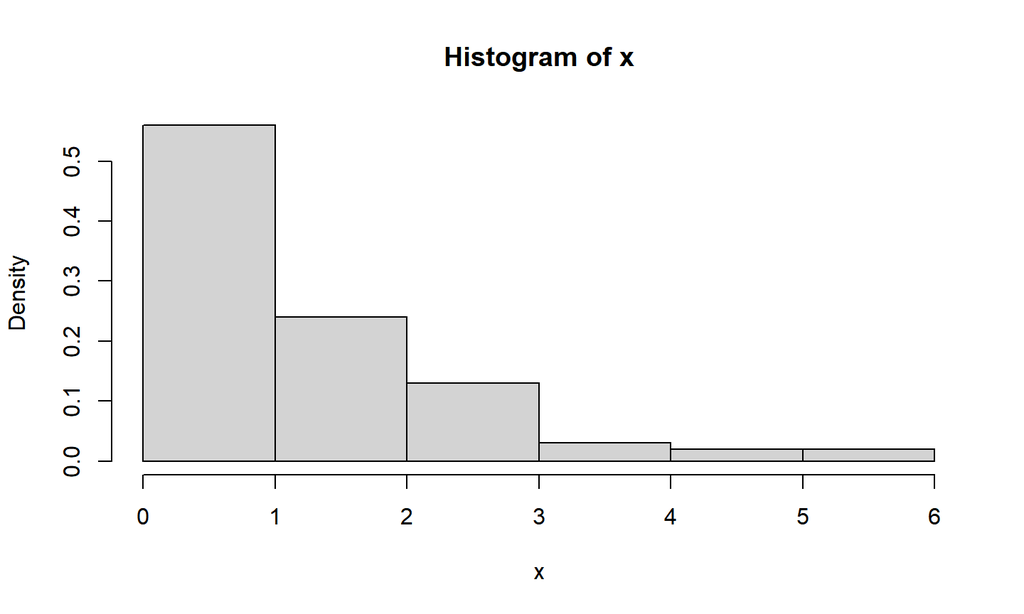

```r
x <- rexp(100,1)
hist(x, prob=TRUE)
```

## Functions

- We might need to compute \(\sin(x) + \cos(x)\) more than once.

```r
sincos <- function(x){
z <- sin(x) + cos(x);
z
}
sincos(1)
```

```
## [1] 1.381773
```

## Basic programming in R

- We will introduce basic programming in R with the following problem
- We will use a *while* loop in R.

By running simulations in R, approximate the average number of rolls of a fair dice it takes before you see a 6.

## The procedure

- We make a function *numrolls* which counts how many times we need to roll a dice until we see a \(6\)
- Use the *replicate* command to repeat this function many times
- Take the average

## The code

```r
numrolls <- function(){
n=0
x=0
while(x <6){
x <- sample(6,1, replace =TRUE)
n <- n+1
}
n
}

mean(replicate(1000, numrolls()) )
```

```
## [1] 5.915
```

## For loop

We illustrate how to write a *for* loop in the context of prime numbers.

Define a function that tells you whether a positive integer is prime or not.

## Background

- Let \(n\) be an integer.
- \(d\) is a divisor of \(n\) if there exists an integer \(c\) such that \(n = cd\).
- An integer \(n \geq 2\) is prime if it only divisors are \(1\) and \(n\).
- R has a built in remainder function, which for nonnegative integers \(a,b\) outputs the remainder in the sense of elementary school, when \(a\) is divided by \(b\).

## Procedure

Using the remainder function we define the *isprime* function, and use it spit out the prime numbers up to 500.

```r
25%%5
```

```
## [1] 0
```

```r
26%%5
```

```
## [1] 1
```

## Code

```r
isprime <- function(n){
x=1
for (i in 2: (n-1)){
if (x >0) {
x <- n%%i
}
}
if (n==1) {x <-0}
if (n==2) {x <-1}
 x
 }
isprime(101)
```

```
## [1] 1
```

```r
x=2
 for(i in 3:500){
if( isprime(i)==1){
x <- c(x, i)}
 x
}
print(x)
```

```
##  [1]   2   3   5   7  11  13  17  19  23  29  31
## [12]  37  41  43  47  53  59  61  67  71  73  79
## [23]  83  89  97 101 103 107 109 113 127 131 137
## [34] 139 149 151 157 163 167 173 179 181 191 193
## [45] 197 199 211 223 227 229 233 239 241 251 257
## [56] 263 269 271 277 281 283 293 307 311 313 317
## [67] 331 337 347 349 353 359 367 373 379 383 389
## [78] 397 401 409 419 421 431 433 439 443 449 457
## [89] 461 463 467 479 487 491 499
```

## Summary

- We introduced some basics of R
- We gave examples programming basics
- Functions
- While loops
- for loops
- the replicate function.

## Version: 4 October 2020